# By_Parts

Stanislav Ilyushin

21 февраля 2020 г

# Второе занятие. Интегрирование по частям.

1. План осовоения:
   - Интегрирование готовых функций
   - Интегрирование функций произведения полинома и циклической
   - Интегрирование произвдения циклических функций
   - Тригонометрические замены и параметрический интеграл

## Введение.

> Дойдя до этой стадии, предполагаю, что читатель уже умеет вносить функции под знак дифференциала, если нет, то предлагаю вернуться на предыдущий урок.

> > В частности, подведение под знак дифференчиала это частный случай интегрирования по частям, только в этом кроется обратный механизм дифференциирования произведения.

Вспомним формулу дифференциирования произведения $(u*v)'= u'*v + v'*u$

Теперь перепишем ее в таком формате $(u*v)'= ud(v) + vd(u)$

Далее, накинем с двух сторон интегралы, равенство само собой не изменится $\int(u*v)'= \int ud(v) + \int vd(u)$

Интеграл взаимно уничтожается с производной и получается $u*v= \int ud(v) + \int vd(u)$

Либо в более красивом “учебническом” виде $\int ud(v) = u*v - \int vd(u)$

> Запомним эту штуку $\int ud(v) = u*v - \int vd(u)$

### Легкая прелюдия

Сейчас я покажу как работать с некоторой табличкой, которая называется “D-I” - вскоре нам понадобятся эти знания.

$D$ $I$

$+$ $a$ $e$

$-$ $b$ $f$

$+$ $c$ $g$

$-$ $d$ $h$

> Выше есть некоторая табличка, которая поможет нам в дальнейнем достаточно быстро решать многие интегралы по частям, не мучаясь с тем “а что же класть в дифференциал, а что вытаскивать из него”

#### Буквы “D-I” обозначают название колонок, чередующиеся знаки означают знаки перед колонкой “D”: допустим, если элемент “b” столбца “D” был бы отрицательным, то, учитывая минус впереди, элемент “b” изменил бы свой знак. Буквы “a, b, c, …” соответственно элементы столбцов.

#### И теперь некоторые ответы, которые можно получить из данной таблички.

$a*f - b*g + c*h - \int d*h$

$a*f - b*g + \int c*g$

$a*f - \int b*f$

> > То есть идея понятна, мы диагонально перемножаем элементы, начиная с первого элемента столбца D, при этом учитывая знаки, и закрываемся последней строчкой в интеграле. Ок!

## Интегрирование по частям.

### Раздел первый. Готовые функции.

Что такое готовые функции? Я не хотел это конечно выделять в подраздел, но для начала самое то. В моем сленге, готовая функция - какая то очень простая функция, которая, по вашей интуиции должна быть в табличке интегралов, но ее почему-то там нет.

> Далее я буду решать интегралы с помощью формулы и таблички.

> Взять что то по частям, как правило, выделить из интеграла две функции, а потом действовать по регламенту

> > Самое главное заблуждение, которое кроется в готовых функциях - это что единица не функция, сейчас мы увидим это.

Плюс таблички - это так сказать “движок” интеграла, посмотреть во внутрь процесса и понять как все работает.

Формула - это неприятная математическая возня, которая может вас легко запутать.

#### Вспоминаем. $\int ud(v) = u*v - \int vd(u)$

$\int ln(x)dx = x*ln(x) - \int x*d(ln(x)) = x*ln(x) - \int x*{\frac{1}{x}}dx = x*ln(x) - \int dx = x*ln(x)- x +C$

> Здесь мы в тупую используем формулу выше, и получилось что нам как бы сама судьба подсказала, что мы должны дифференциировать логарифм, а интегрировать единицу.

Теперь заглянем под движок сея процесса, помним таблицу?

Раскрываю карты, столбик “D” - это та часть функции, от которой мы берем производные, то есть постоянно выниманием из под дифференциала во второй части, в нашем случае мы одни раз “вынули” логарифм, а стобик “I” - это то, что мы засовываем под дифференциал в первом шаге в левой части уравнения, в нашем случае это была единица.

$D$ $I$

$+$ $ln(x)$ $1$

$-$ ${\frac{1}{x}}$ $x$

$+$ $-{\frac{1}{x^2}}$ ${\frac{x^2}{2}}$

> > Данную табличку можно расписывать бесконечно долго. Продемонстрирую равносильность интераций, те когда бы мы ни остановили данный процесс - ответы сходятся. Но сами понимаете: чем дольше, тем больше считать.

#### 1 шаг.

$\int ln(x)dx = ln(x)*x - \int {\frac{1}{x}} *xdx = ln(x)*x -x +C$

#### 2 шага.

$\int ln(x)dx = ln(x)*x - {\frac{1}{x}}*{\frac{x^2}{2}} - \int {\frac{1}{x^2}}*{\frac{x^2}{2}}dx = ln(x)*x - 0.5x - 0.5x + C = x*ln(x) -x +C$

Движимся далее, арктангенс.

С помощью формулы.

$\int {\arctan{x}}dx = x*{\arctan(x)}-\int x*d({\arctan(x)}) = x*{\arctan(x)}-\int {\frac{x*dx}{1+x^2}} = x*arctan - {\frac{1}{2}}*ln|1+x^2|+C$

## Полином и циклическая.

Как я уже писал выше, главной задачей интегрировании по частям является выбор того, что нас дифференциировать, а что интегрировать. В случае полинома и циклической функции все предельно просто. На каком нибудь из шагов производная убьет полином в 0, и тогда дело в шляпе.В ИТОГЕ, если по формуле, ЗАСОВЫВАЕМ ЦИКЛИЧЕСКУЮ.

> Те, мы будем работать с такими вещами $\int P^n(m)*(sin(x)/cos(x)/e^x) dx$

> > Почему они циклические? Потому что их производные и первообразные обращаются сами в себя.

#### Интеграл 1.

$\int sin(x)*(x^2)dx$

По формуле.

$\int sin(x)*(x^2)dx = -\int x^2*d(cos(x))=-x^2*cos(x)+\int cos(x)*d(x^2)= -x^2*cos(x)+ \int 2x*cos(x)dx =$

Еще раз ЗАСОВЫВАЕМ (теперь уже косинус)

$=-x^2*cos(x)+ \int 2x*cos(x)dx = -x^2*cos(x) +2* \int xd(sin(x))=-x^2*cos(x) +2x*sin(x)-2\int sin(x)dx = -x^2*cos(x) +2x*sin(x) +2*cos(x)+C$

Сделаю это через табличку, только с $e^x$, и далее буду использовать только ее, так как это гораздо удобнее, в том числе и код писать.

#### Интеграл 2.

$\int e^{-5x}* (x^2-x+6)dx$ (дифференциируем полином).

$D$ $I$

$+$ $(x^2-x+6)$ $e^{-5x}$

$-$ $(2x-1)$ $(-{\frac{1}{5}})*e^{-5x}$

$+$ $2$ $({\frac{1}{25}})*e^{-5x}$

$-$ $0$ $(-{\frac{1}{125}})e^{-5x}$

$\int e^{-5x}* (x^2-x+6)dx = -(x^2-x+6)*{\frac{1}{5}}*e^{-5x} - (2x-1)*{\frac{1}{25}}*e^{-5x} - 2*{\frac{1}{125}}*e^{-5x} + 0 + C$

Принцип потян, дифференциируем полином до нуля, чтобы наша последняя а-ля интегральная строчка давала ноль.

## Две циклических.

> На моей памяти из циклических функций (чьи производные и первообразные не меняются) всего 3 - $e^x , cos(x), sin(x)$, не учитывая конечно гиперболических вариаций.

> > Самый избитый метод в этом плане - сведение к повторному интегралу, те чтобы в нашей таблице последняя строчка была идентична до множителя с исходным интегралом.

#### Например. $\int e^xsin(x)dx$

Единтсвенный плюс этой формы, что нам все равно, что выбирать для дифференциирования, а что для интегрирования, в отличии от предыдущих номеров.

$D$ $I$

$+$ $sin(x)$ $e^x$

$-$ $cos(x)$ $e^x$

$+$ $-sin(x)$ $e^x$

Останавливаемся на 3 строчке и собираем табличку.

$\int e^xsin(x)dx= e^xsin(x)-e^xcos(x)-\int e^xsin(x)dx$

Переносим интегралы в одну сторону и получаем:

$2* \int e^xsin(x)dx= e^xsin(x)-e^xcos(x)$ либо $\int e^xsin(x)dx= {\frac{1}{2}}( e^xsin(x)-e^xcos(x))$

#### Принцип понятен. Теперь приведу общее решение интеграла $\int e^{ax}*(sin(bx)/cos(bx))dx$ для любителей математики (?).

> > Hint: $e^{ix}=cos(x)+isin(x)$

Начнем с интеграла $\int e^{ax}cos(bx)dx$ далее приведем его к виду $\int e^{f(ix)}dx$, добавив к нему $i\int e^{ax}sin(bx)dx$

$\int e^{ax}cos(bx)dx + i\int e^{ax}sin(bx)dx = \int e^{ax}(cos(bx)+isin(bx))dx = \int e^{ax}*e^{ixb} dx = \int e^{x(a+bi)}dx = {\frac{e^{x(a+bi)}}{a+bi}}$

Преобразуем ${\frac{e^{x(a+bi)}}{a+bi}}$ домножив на сопряженное комплексное число.

${\frac{e^{x(a+bi)}}{a+bi}} = e^{ax}*{\frac{e^{xbi}(a-bi)}{(a+bi)(a-bi)}} = {\frac{e^{ax}}{a^2+b^2}}*e^{xbi}(a-bi)$

Теперь раскроем экспоненту, домножим на скобку, выделив действительную и комплексную части.

$e^{ax}*{\frac{e^{xbi}(a-bi)}{(a+bi)(a-bi)}} = {\frac{e^{ax}}{a^2+b^2}}*e^{xbi}(a-bi) = {\frac{e^{ax}}{a^2+b^2}}(cos(bx)+isin(bx))(a-bi)= {\frac{e^{ax}}{a^2+b^2}}(a*cos(bx)-ib*cos(bx)+ia*sin(bx)+b*sin(bx))$

> Действительная часть без “i”, комплексная соотвественно с “i”

$\int e^{ax}cos(bx)dx = Re({\frac{e^{x(a+bi)}}{a+bi}})= {\frac{e^{ax}}{a^2+b^2}}(a*cos(bx)+b*sin(bx))$

$\int e^{ax}sin(bx)dx = Im({\frac{e^{x(a+bi)}}{a+bi}})={\frac{e^{ax}}{a^2+b^2}}(a*sin(bx)-b*cos(bx))$

#### Решим еще один похожий пример переноса интеграл в мир формулы Эйлера.

#### $\int cos(ln(x))dx , \int sin(ln(x))dx$

По традиции начнем с $\int cos(ln(ax))dx$ добавив к нему $i\int sin(ln(ax))dx$

$\int cos(ln(ax))dx + i\int sin(ln(ax))dx = \int e^{i*ln(ax)}dx = \int (ax)^idx= a^i({\frac{x^{i+1}}{i+1}})$

Шаги те же. Сопряженное число и выделение действительной и комплесной части.

$a^i({\frac{x^{i+1}}{i+1}}) = a^i({\frac{x^{1+i}(1-i)}{(1+i)(1-i)}})= a^i({\frac{x}{2}}*x^i(1-i))=a^i({\frac{x}{2}}*(cos(ln(x))+isin(ln(x)))(1-i))= ({\frac{x}{2}}*(a^icos(ln(x))+a^i*isin(ln(x)))(1-i))= {\frac{x}{2}}(cos(ln(ax))-icos(ln(ax))+isin(ln(ax))+sin(ln(ax)))$

$\int cos(ln(x)) dx = Re({\frac{x^{i+1}}{i+1}})= {\frac{x}{2}}(cos(ln(ax))+sin(ln(ax)))$

$\int sin(ln(x))dx = Im({\frac{x^{i+1}}{i+1}})={\frac{x}{2}}(sin(ln(ax))-cos(ln(ax)))$

### Последняя часть.

#### Здесь мы поговорим об интегрировании очень распрстраненных вещей:

#### $\int{\sqrt {a^2 - x^2}}dx, \int{\sqrt {x^2 - a^2}}dx, \int{\sqrt {a^2 + x^2}}dx$

Сначала попробуем каждый взять по частям, это одни из немногих интегралов, которые выглядят “сложно”, но берутся, как самая первая группа, где нужно интегрировать $1$

#### НОМЕР 1 $\int{\sqrt {a^2 - x^2}}dx$

$D$ $I$

$+$ ${\sqrt {a^2 - x^2}}$ $1$

$-$ $-{\frac{x}{{\sqrt {a^2-x^2}}}}$ $x$

Останавливаемся на второй строчке, в которой уже видна интегрируемая часть.

$\int{\sqrt {a^2 - x^2}}dx = x*{\sqrt {a^2 - x^2}} + \int {\frac{x^2}{{\sqrt {a^2-x^2}}}}dx = x*{\sqrt {a^2 - x^2}} + \int {\frac{x^2 +a^2 - a^2}{{\sqrt {a^2-x^2}}}}dx$

Я добавил и вычел $a^2$ чтобы интеграл свелся к повтороному и табличному

> > Если видите в интеграле что-то очень похожее, и вот-вот оно должно сократиться, но не хватает какой-то константы - смело добавляйте и вычитайте

$\int{\sqrt {a^2 - x^2}}dx = x*{\sqrt {a^2 - x^2}} - \int {\sqrt {a^2-x^2}}dx + \int {\frac{a^2}{{\sqrt {a^2-x^2}}}}dx$

$\int{\sqrt {a^2 - x^2}}dx ={\frac{1}{2}}( x*{\sqrt {a^2 - x^2}} + a^2{\arcsin({\frac{x}{a}})})+C$

#### НОМЕР 2 $\int{\sqrt {x^2 - a^2}}dx$

$D$ $I$

$+$ ${\sqrt {x^2 - a^2}}$ $1$

$-$ ${\frac{x}{{\sqrt {x^2-a^2}}}}$ $x$

$\int{\sqrt {x^2 - a^2}}dx = x*{\sqrt {x^2 - a^2}} - \int {\frac{x^2}{{\sqrt {x^2-a^2}}}}dx = x*{\sqrt {x^2 - a^2}} - \int {\frac{x^2 +a^2 - a^2}{{\sqrt {x^2-a^2}}}}dx$

$\int{\sqrt {x^2 - a^2}}dx = x*{\sqrt {x^2 - a^2}} - \int {\sqrt {x^2-a^2}}dx - \int {\frac{a^2}{{\sqrt {x^2-a^2}}}}dx$

$\int{\sqrt {x^2 - a^2}}dx ={\frac{1}{2}}( x*{\sqrt {x^2 - a^2}} - a^2*ln|x+{\sqrt {x^2-a^2}}|)+C$

#### НОМЕР 3 $\int{\sqrt {x^2 + a^2}}dx$

$D$ $I$

$+$ ${\sqrt {x^2 + a^2}}$ $1$

$-$ ${\frac{x}{{\sqrt {x^2+a^2}}}}$ $x$

$\int{\sqrt {x^2 + a^2}}dx = x*{\sqrt {x^2 + a^2}} - \int {\frac{x^2}{{\sqrt {x^2+a^2}}}}dx = x*{\sqrt {x^2 + a^2}} - \int {\frac{x^2 +a^2 - a^2}{{\sqrt {x^2+a^2}}}}dx$

$\int{\sqrt {x^2 - a^2}}dx = x*{\sqrt {x^2 +a^2}} - \int {\sqrt {x^2+a^2}}dx + \int {\frac{a^2}{{\sqrt {x^2+a^2}}}}dx$

$\int{\sqrt {x^2 + a^2}}dx ={\frac{1}{2}}( x*{\sqrt {x^2 + a^2}} + a^2*ln|x+{\sqrt {x^2+a^2}}|)+C$

### А как делать с заменами?

#### Сейчас дам замены для всех случаев, и один из них мы сможем решить.

> > Hint: $1+{\tan^2(x)} = {\frac{1}{{\cos^2(x)}}}$, ${\cos^2(x)}={\frac{1+cos(2x)}{2}}$
1. $\int{\sqrt {a^2 - x^2}}dx$
   - $x= a*sin(t)$
   - $dx= a*cos(t)dt$
   - $t= arcsin({\frac{x}{a}})$

$\int{\sqrt {a^2 - x^2}}dx = \int{\sqrt {a^2 - a^2*{\sin^2(t)}}}*a*{\cos(t)}dt=\int a^2*{\cos^2(t)}dt$

2. $\int{\sqrt {a^2 + x^2}}dx$
   - $x= a*tan(t)$
   - $dx= {\frac{a*dt}{{\cos^2(t)}}}$
   - $t=arctan({\frac{x}{a}})$

$\int{\sqrt {a^2 + x^2}}dx = \int{\sqrt {a^2 + a^2*{\tan^2(t)}}}*{\frac{a*dt}{{\cos^2(t)}}}=\int {\frac{a^2*dt}{{\cos^3(t)}}}$

3. $\int{\sqrt {x^2 - a^2}}dx$
   - $x= {\frac{a}{cos(t)}}$
   - $dx= {\frac{a*sin(t)*dt}{{\cos^2(t)}}}$
   - $t=arccos({\frac{a}{x}})$

$\int{\sqrt {x^2 - a^2}}dx = \int{\sqrt {{\frac{a^2}{{\cos^2(t)}}} - a^2}}*{\frac{a*sin(t)*dt}{{\cos^2(t)}}}=\int {\frac{a^2*{\sin^2(t)}*dt}{{\cos^3(t)}}}$

Поссчитаем 1 интеграл, два других мы тоже сможем взять, просто это займет гораздо больше времени. (по частям)

$\int a^2*{\cos^2(t)}dt = a^2 \int {\frac{1+cos(2t)}{2}}dt={\frac{a^2}{2}}(t+{\frac{sin(2t)}{2}})$

Где $t=arcsin({\frac{x}{a}})$

$sin(2arcsin({\frac{x}{a}}))=2*sin(arcsin({\frac{x}{a}}))*cos(arcsin({\frac{x}{a}}))=2*({\frac{x}{a}})*({\frac{{\sqrt {a^2-x^2}}}{a}})$

> > $sin(arcsin(x))=x$, $cos(arcsin(x))$ ищется как косинус угла из треугольника с противопложным катетом $x$ и гипотенузой $1$ тк синус данного угла равен $x$, что есть отношение противоположного катета и гипотенузы.

$\int a^2*{\cos^2(t)}dt = {\frac{a^2}{2}}(arcsin({\frac{x}{a}})+{\frac{x*{\sqrt {a^2-x^2}}}{a^2}})+C$

### Последний сюжет. Параметрическое представление.

Что такое неопределенный интеграл? Какая-то функция. Что такое определенный интгерал? Число или площадь под графиком. А что будет, если задать площадь по какой-то переменной? Параметрический интеграл. Чей ответ какая-то функция, зависящая от параметра. А равна ли функция из неопределенного интеграла и функция из параметрического? Да! С точностью до константы.

$\int f(x) dx= \int_{}^x f(t)dt$

> В общем, для функций с осью симметрии, нам не важен нижний предел интегрирования, так как площадь под графиком дальше оси симметрии не зависит от $x$ и уходит в константу. Для более сложных функций нужно подбирать суммы разбиений в зависимости от осей симметрии графика.

> > Несмотря на то, что мы сейчас очень быстро посчитаем интеграл, советую использовать данный метод только в экстренных случаях, так как не всегда удастся посчитать площадь под графиком.

(смотрим картинку)

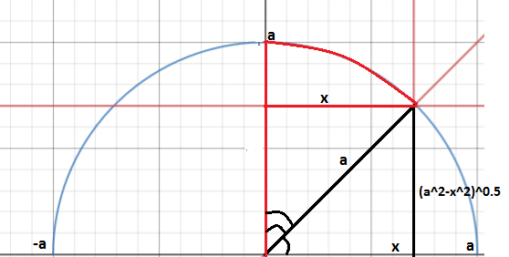

${\sqrt {a^2-x^2}}$

#### Ищем $\int {\sqrt {a^2-x^2}}dx$ через параметрическую площадь

На графике изображена функция полуокружности с радиусом $a$

Выберем пределы интегрирования: $\int {\sqrt {a^2-x^2}}dx= \int_{0}^x {\sqrt {a^2-t^2}}dt$

> Нижний предел не особо важен, главное, чтобы он не вылезал за радиус полуокружности и не совпадал с верхним предлом, с $0$ просто легче считать, если мы бы взяли с отрицательной стороны - эта площадь не зависит от $x$, если с положительной - очень сложно считать площадь.

> > Если так и делать, то брать нижний предел максимально удобным для подсчета площадей.

В данном случае нам надо найти площадь под полуокружностью от $0$ до $x$. Эта площадь разбивается на черный треугольник и красный сектор окружности.

> > $S(trian)= 0.5ah$ $S(sect)=0.5r^2*(angle)$

Найдем площадь треугольника. Основание $=x$, гипотенуза это радиус $=a$, следовательно противоположный катет = ${\sqrt {a^2-x^2}}$, а площадь всего треугольника $S={\frac{1}{2}}x{\sqrt {a^2-x^2}}$

Найдем площадь сектора по формуле выше. Угол, на котором лежит сектор равен $angle2=arcsin({\frac{x}{a}})$. Видим выполнения равенства. Острый угол треугольника $angle1=arccos({\frac{x}{a}})$. ${\frac{\pi}{2}}=arcsin(x)+arccos(x)$.

Итого площадь сектора: $S(sect) = {\frac{1}{2}}*a^2*arcsin({\frac{x}{a}})$

$\int {\sqrt {a^2-x^2}}dx= \int_{0}^x {\sqrt {a^2-t^2}}dt = {\frac{1}{2}}*a^2*arcsin({\frac{x}{a}}) + {\frac{1}{2}}x{\sqrt {a^2-x^2}} + C$

### Ура! Бинго!

#### Если у вас есть СЛОЖНЫЕ интегралы, которые не можете решить ни вы, ни ваши знакомые, родители и соседи. Присылайте [мне](https://vk.com/stasilyushin), решу и в скором времени выложу это в отдельный тег “Сложные интегралы”. ПЛЗ только не из Демидовича, он уже тысячу раз прорешан.

[Back to the openning page](https://stanislavii.github.io/ranepa_integrals.github.io/)